# Area Plots, Histograms, and Bar Charts

## What I'm Doing

In this lab, I'm learning how to create and customize three essential types of data visualizations - area plots, histograms, and bar charts - using Python's Matplotlib library.

## 1. Setting Up

First, I import the core libraries I'll need: NumPy for numerical operations, pandas for data manipulation, and Matplotlib for plotting.

```
import numpy as np
import pandas as pd
import matplotlib as mpl
import matplotlib.pyplot as plt

%matplotlib inline # ensures plots render directly in the notebook
mpl.style.use('ggplot') # for a clean, modern look
print('Matplotlib version: ', mpl.__version__)
```

```
Matplotlib version:  3.10.9
```

## 2. Getting to Know the Dataset

The dataset contains immigration figures to Canada from various countries, spanning the years 1980 to 2013.

```
df_can = pd.read_csv('https://cf-courses-data.s3.us.cloud-object-storage.appdomain.cloud/IBMDeveloperSkillsNetwork-DV0101EN-SkillsNetwork/Data%20Files/Canada.csv')
```

Let's peek at the first few rows to understand the structure:

```
df_can.head()
```

|  | Country | Continent | Region | DevName | 1980 | 1981 | 1982 | 1983 | 1984 | 1985 | ... | 2005 | 2006 | 2007 | 2008 | 2009 | 2010 | 2011 | 2012 | 2013 | Total |
| --- | --- | --- | --- | --- | --- | --- | --- | --- | --- | --- | --- | --- | --- | --- | --- | --- | --- | --- | --- | --- | --- |
| 0 | Afghanistan | Asia | Southern Asia | Developing regions | 16 | 39 | 39 | 47 | 71 | 340 | ... | 3436 | 3009 | 2652 | 2111 | 1746 | 1758 | 2203 | 2635 | 2004 | 58639 |
| 1 | Albania | Europe | Southern Europe | Developed regions | 1 | 0 | 0 | 0 | 0 | 0 | ... | 1223 | 856 | 702 | 560 | 716 | 561 | 539 | 620 | 603 | 15699 |
| 2 | Algeria | Africa | Northern Africa | Developing regions | 80 | 67 | 71 | 69 | 63 | 44 | ... | 3626 | 4807 | 3623 | 4005 | 5393 | 4752 | 4325 | 3774 | 4331 | 69439 |
| 3 | American Samoa | Oceania | Polynesia | Developing regions | 0 | 1 | 0 | 0 | 0 | 0 | ... | 0 | 1 | 0 | 0 | 0 | 0 | 0 | 0 | 0 | 6 |
| 4 | Andorra | Europe | Southern Europe | Developed regions | 0 | 0 | 0 | 0 | 0 | 0 | ... | 0 | 1 | 1 | 0 | 0 | 0 | 0 | 1 | 1 | 15 |

5 rows × 39 columns

```
print(df_can.shape)
```

```
(195, 39)
```

So we have **195 countries** (rows) and **39 columns** (country info + yearly immigration data from 1980 to 2013 plus a `Total` column).

## 3. Cleaning the Data

The dataset is already fairly clean, but there's one key transformation: I'll **set the `Country` column as the index**. This will make it easy to look up specific countries using the `.loc` accessor.

```
df_can.set_index('Country', inplace=True)
df_can.head()
```

| Country | Continent | Region | DevName | 1980 | 1981 | 1982 | 1983 | 1984 | 1985 | 1986 | ... | 2005 | 2006 | 2007 | 2008 | 2009 | 2010 | 2011 | 2012 | 2013 | Total |
| --- | --- | --- | --- | --- | --- | --- | --- | --- | --- | --- | --- | --- | --- | --- | --- | --- | --- | --- | --- | --- | --- |
| Afghanistan | Asia | Southern Asia | Developing regions | 16 | 39 | 39 | 47 | 71 | 340 | 496 | ... | 3436 | 3009 | 2652 | 2111 | 1746 | 1758 | 2203 | 2635 | 2004 | 58639 |
| Albania | Europe | Southern Europe | Developed regions | 1 | 0 | 0 | 0 | 0 | 0 | 1 | ... | 1223 | 856 | 702 | 560 | 716 | 561 | 539 | 620 | 603 | 15699 |
| Algeria | Africa | Northern Africa | Developing regions | 80 | 67 | 71 | 69 | 63 | 44 | 69 | ... | 3626 | 4807 | 3623 | 4005 | 5393 | 4752 | 4325 | 3774 | 4331 | 69439 |
| American Samoa | Oceania | Polynesia | Developing regions | 0 | 1 | 0 | 0 | 0 | 0 | 0 | ... | 0 | 1 | 0 | 0 | 0 | 0 | 0 | 0 | 0 | 6 |
| Andorra | Europe | Southern Europe | Developed regions | 0 | 0 | 0 | 0 | 0 | 0 | 2 | ... | 0 | 1 | 1 | 0 | 0 | 0 | 0 | 1 | 1 | 15 |

5 rows × 38 columns

Now the country names serve as row indices. Let's confirm the dimensions and create a handy list of year strings:

```
print('data dimensions:', df_can.shape)

years = list(map(str, range(1980, 2014)))
```

```
data dimensions: (195, 38)
```

This `years` list will come in handy for slicing columns when plotting.

## 4. Area Plots

**Area plots** (or **stacked line plots**) are great for visualizing how multiple categories contribute to a total over time. Let's start by identifying the **top 5 countries that contributed the most immigrants** to Canada.

```
df_can.sort_values(['Total'], ascending=False, axis=0, inplace=True)

df_top5 = df_can.head() # get the top 5 entries

df_top5 = df_top5[years].transpose()

df_top5.head()
```

| Country | India | China | United Kingdom of Great Britain and Northern Ireland | Philippines | Pakistan |
| --- | --- | --- | --- | --- | --- |
| 1980 | 8880 | 5123 | 22045 | 6051 | 978 |
| 1981 | 8670 | 6682 | 24796 | 5921 | 972 |
| 1982 | 8147 | 3308 | 20620 | 5249 | 1201 |
| 1983 | 7338 | 1863 | 10015 | 4562 | 900 |
| 1984 | 5704 | 1527 | 10170 | 3801 | 668 |

After transposing, each column is a country and the index is the year. Let me also convert the index to integers for cleaner plotting:

```
df_top5.index = df_top5.index.map(int)
```

Now **I'll create an unstacked area** plot:

Area plots are **stacked by default**. And to produce a stacked area plot, each column must be either all positive or all negative values (any `NaN`, i.e. not a number, values will default to 0). **To produce an unstacked plot**, set parameter `stacked` to **value `False`**.

### Two Plotting Styles

**Method 1 (Scripting layer / procedural)** - using `plt.*` functions:

```
df_top5.plot(kind='area',
             stacked=False,
             figsize=(20, 10))

plt.title('Immigration Trend of Top 5 Countries')
plt.ylabel('Number of Immigrants')
plt.xlabel('Years')
plt.show()
```

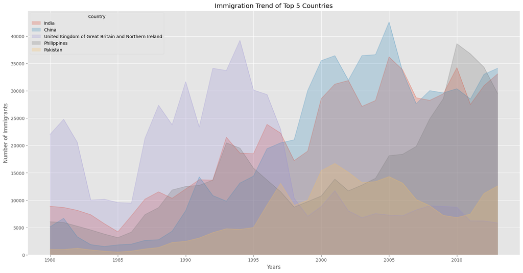

**`Result:`** An area plot with five overlapping shaded regions (one per country), showing immigration trends from 1980 to 2013.

**Method 2 (Artist layer / object-oriented)** - using an `Axes` instance. This is often preferred for more control.

```
ax = df_top5.plot(kind='area', alpha=0.35, stacked=False, figsize=(20, 10))
ax.set_title('Immigration Trend of Top 5 Countries')
ax.set_ylabel('Number of Immigrants')
ax.set_xlabel('Years'); # semicolon tu suppress "Text(0.5, 0, 'Years')" Text
```

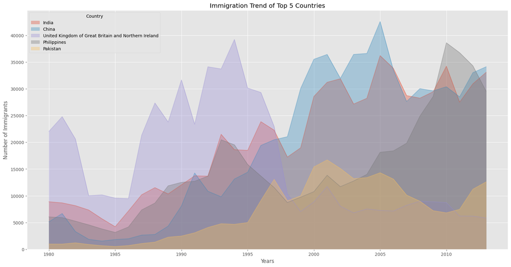

**`Result:`** Both produce identical plots - the difference is in how you modify plot elements.

### **Exercise**: Least Contributing Countries - Stacked Area Plot (**Scripting Layer**)

**Task:** Use the **scripting layer** to create a **stacked** area plot of the **5 countries that contributed the least** to immigration to Canada from 1980 to 2013, with a transparency of 0.45.

```
df_least5 = df_can.tail(5)

df_least5 = df_least5[years].transpose()

df_least5.index = df_least5.index.map(int)

df_least5.plot(kind='area', alpha=0.45, figsize=(20, 10))

plt.title('Immigration Trend of 5 Countries with Least Contribution to Immigration')
plt.ylabel('Number of Immigrants')
plt.xlabel('Years')
plt.show()
```

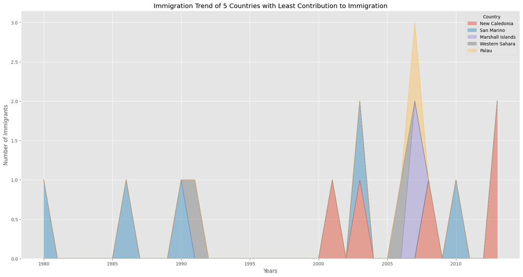

**`Result:`** Immigration from these countries is not a smooth upward trend but rather event‑driven, with sharp spikes in specific years

### Exercise: Least Contributing Countries - Unstacked Area Plot (**Artist Layer**)

**Task:** Use the **artist layer** to create an **unstacked** area plot of the **5 least-contributing countries**, with a transparency of 0.55.

```
df_least5 = df_can.tail(5)

df_least5 = df_least5[years].transpose()

df_least5.index = df_least5.index.map(int)

ax = df_least5.plot(kind='area', alpha=0.55, stacked=False, figsize=(20, 10))

ax.set_title('Immigration Trend of 5 Countries with Least Contribution to Immigration')
ax.set_ylabel('Number of Immigrants')
ax.set_xlabel('Years')
plt.show()
```

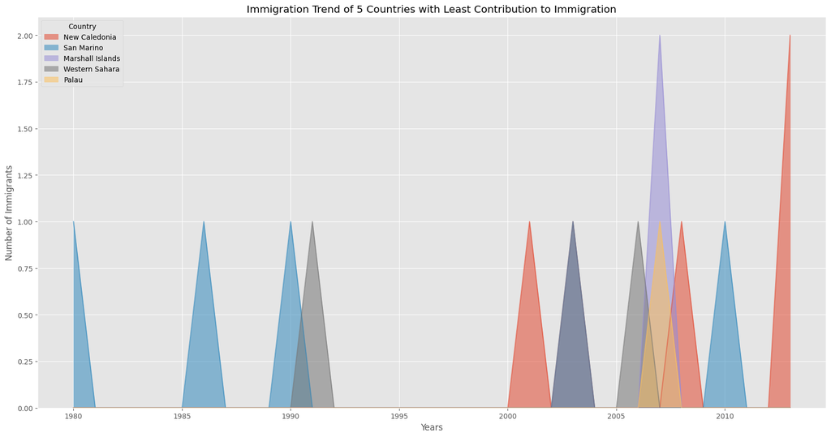

The scripting layer (`plt.*`) is simpler for quick plots; the artist layer (`ax.*`) scales better for complex, multi-plot layouts.

## 5. Histograms

Histograms **show the frequency distribution of a numeric variable** - they group data into bins along the x-axis and count how many observations fall into each bin.

Let's examine the distribution of immigration counts across all countries for the year 2013.

```
df_can['2013'].head()
```

```
Country
India                                                   33087
China                                                   34129
United Kingdom of Great Britain and Northern Ireland     5827
Philippines                                             29544
Pakistan                                                12603
Name: 2013, dtype: int64
```

I can use NumPy's `histogram` function to see how the data gets split into bins:

```
count, bin_edges = np.histogram(df_can['2013'])
print(count) # frequency count
print(bin_edges) # bin ranges, default = 10 bins
```

```
[178  11   1   2   0   0   0   0   1   2]
[    0.   3412.9  6825.8 10238.7 13651.6 17064.5 20477.4 23890.3 27303.2
 30716.1 34129. ]
```

So in 2013:

- **178 countries** contributed between 0 and ~3,413 immigrants
- **11 countries** contributed between ~3,413 and ~6,826 immigrants
- And so on — most countries send relatively few immigrants, while a handful send many.

Let's plot this as a histogram:

```
df_can['2013'].plot(kind='hist', figsize=(8, 5)) # kind='hist'

plt.title('Histogram of Immigration from 195 Countries in 2013')
plt.ylabel('Number of Countries')
plt.xlabel('Number of Immigrants')
plt.show()
```

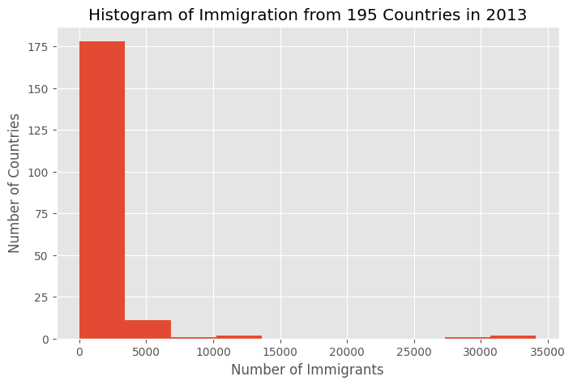

**`Result:`** A histogram with a **heavily right-skewed** distribution - most countries cluster in the first bin (low immigration), with a **long tail** of a few high-immigration countries.

The x-axis tick labels don't match the bin edges by default. Let's fix that:

```
count, bin_edges = np.histogram(df_can['2013']) # xticks=bin_edges

df_can['2013'].plot(kind='hist', figsize=(8, 5), xticks=bin_edges)

plt.title('Histogram of Immigration from 195 countries in 2013')
plt.ylabel('Number of Countries')
plt.xlabel('Number of Immigrants')
plt.show()
```

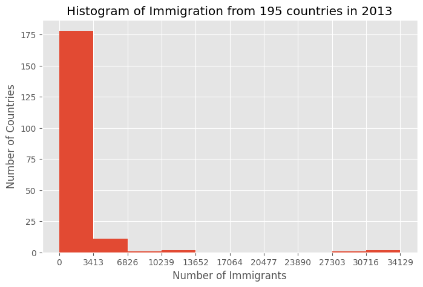

**`Result:`** Same histogram, but now the x-axis ticks line up with the actual bin boundaries, making it easier to read the ranges.

**Side Note:** **df_can['2013'].plot.hist()** is equivalent to **df_can.plot(kind='hist', ...)**. Can be used interchangeably.

### Exercise: Immigration Distribution for Denmark, Norway, and Sweden

**Task:** What is the immigration distribution for Denmark, Norway, and Sweden from 1980 to 2013?

First, let's look at the data:

```
df_can.loc[['Denmark', 'Norway', 'Sweden'], years]
```

| Country | 1980 | 1981 | 1982 | 1983 | 1984 | 1985 | 1986 | 1987 | 1988 | 1989 | ... | 2004 | 2005 | 2006 | 2007 | 2008 | 2009 | 2010 | 2011 | 2012 | 2013 |
| --- | --- | --- | --- | --- | --- | --- | --- | --- | --- | --- | --- | --- | --- | --- | --- | --- | --- | --- | --- | --- | --- |
| Denmark | 272 | 293 | 299 | 106 | 93 | 73 | 93 | 109 | 129 | 129 | ... | 89 | 62 | 101 | 97 | 108 | 81 | 92 | 93 | 94 | 81 |
| Norway | 116 | 77 | 106 | 51 | 31 | 54 | 56 | 80 | 73 | 76 | ... | 73 | 57 | 53 | 73 | 66 | 75 | 46 | 49 | 53 | 59 |
| Sweden | 281 | 308 | 222 | 176 | 128 | 158 | 187 | 198 | 171 | 182 | ... | 129 | 205 | 139 | 193 | 165 | 167 | 159 | 134 | 140 | 140 |

3 rows × 34 columns

If I plot this directly:

```
df_can.loc[['Denmark', 'Norway', 'Sweden'], years].plot.hist();
```

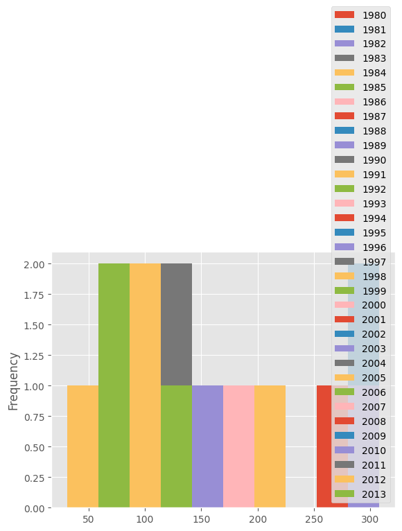

The result is wrong - pandas plots the frequency distribution of *years*, not countries. The fix is to **transpose** the data so that countries become columns and years become rows, then plot.

```
df_t = df_can.loc[['Denmark', 'Norway', 'Sweden'], years].transpose()
df_t.head()
```

| Country | Denmark | Norway | Sweden |
| --- | --- | --- | --- |
| 1980 | 272 | 116 | 281 |
| 1981 | 293 | 77 | 308 |
| 1982 | 299 | 106 | 222 |
| 1983 | 106 | 51 | 176 |
| 1984 | 93 | 31 | 128 |

Now plot:

```
df_t.plot(kind='hist', figsize=(10, 6))

plt.title('Histogram of Immigration from Denmark, Norway, and Sweden from 1980 - 2013')
plt.ylabel('Number of Years')
plt.xlabel('Number of Immigrants')
plt.show()
```

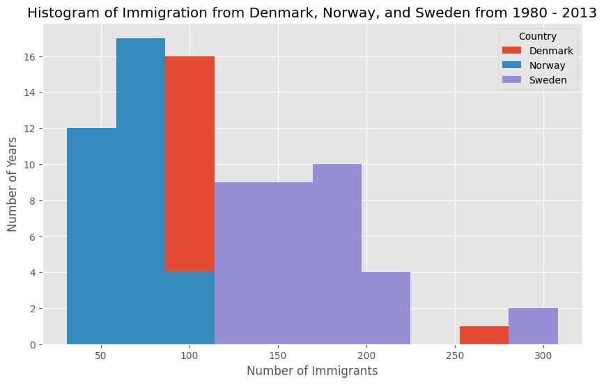

**`Result:`** A histogram with three overlapping distributions. Now each bar represents how many years a country's immigration fell within a given range.

Let's refine it - increase bins to 15, adjust transparency, and use custom colors:

```
count, bin_edges = np.histogram(df_t, 15)

df_t.plot(kind='hist',
          figsize=(10, 6),
          bins=15,
          alpha=0.6,
          xticks=bin_edges,
          color=['coral', 'darkslateblue', 'mediumseagreen']
         )

plt.title('Histogram of Immigration from Denmark, Norway, and Sweden from 1980 - 2013')
plt.ylabel('Number of Years')
plt.xlabel('Number of Immigrants')
plt.show()
```

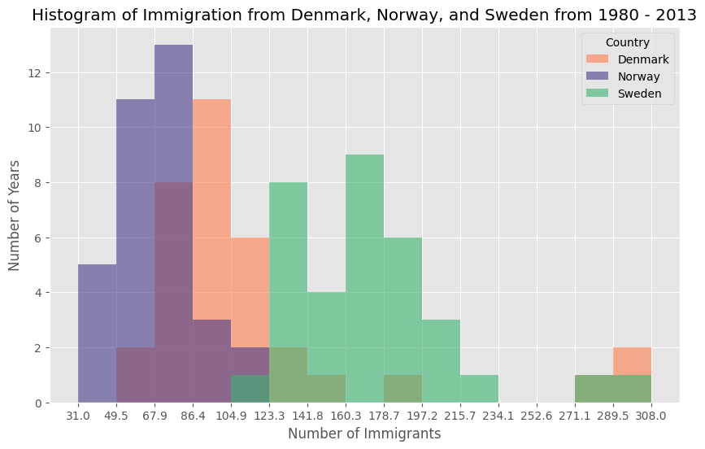

**`Result:`** A cleaner overlapping histogram (**unstacked**) with 15 bins and distinct colors per country.

I can also **stack** them to avoid overlap:

```
count, bin_edges = np.histogram(df_t, 15)
xmin = bin_edges[0] - 10 #  first bin value is 31.0, adding buffer of 10 for aesthetic purposes
xmax = bin_edges[-1] + 10 #  last bin value is 308.0, adding buffer of 10 for aesthetic purposes

df_t.plot(kind='hist',
          figsize=(10, 6),
          bins=15,
          alpha=0.6,
          xticks=bin_edges,
          color=['coral', 'darkslateblue', 'mediumseagreen'],
          stacked=True,
          xlim=(xmin, xmax) #trim x-axis limits
         )

plt.title('Histogram of Immigration from Denmark, Norway, and Sweden from 1980 - 2013')
plt.ylabel('Number of Years')
plt.xlabel('Number of Immigrants')
plt.show()
```

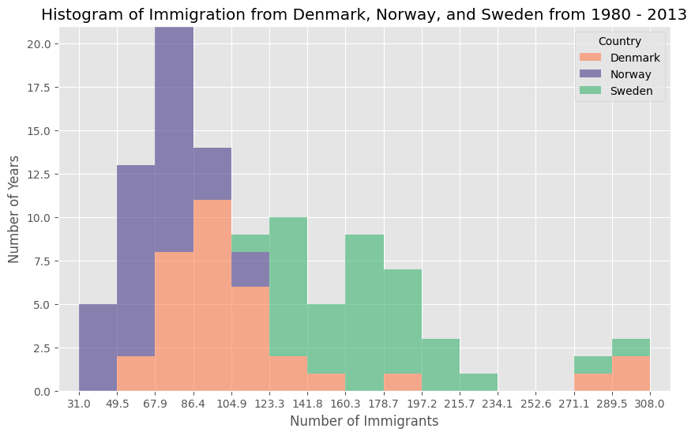

**`Result:`** A **stacked** histogram where the bars are layered on top of each other rather than overlapping. The x-axis limits are also trimmed to remove excess whitespace.

**Tip**: Check full listing of colors available:

```
import matplotlib
for name, hex in matplotlib.colors.cnames.items():
    print(name, hex)
```

### Exercise: Immigration Distribution for Greece, Albania, and Bulgaria (Scripting Layer)

**Task:** Use the scripting layer to display the immigration distribution for Greece, Albania, and Bulgaria from 1980 to 2013. Use 15 bins and alpha = 0.35.

```
df_cof = df_can.loc[['Greece', 'Albania', 'Bulgaria'], years]

df_cof = df_cof.transpose()

count, bin_edges = np.histogram(df_cof, 15)

df_cof.plot(kind='hist',
            figsize=(10, 6),
            bins=15,
            alpha=0.35,
            xticks=bin_edges,
            color=['coral', 'darkslateblue', 'mediumseagreen']
           )

plt.title('Histogram of Immigration from Greece, Albania, and Bulgaria from 1980 - 2013')
plt.ylabel('Number of Years')
plt.xlabel('Number of Immigrants')
plt.show()
```

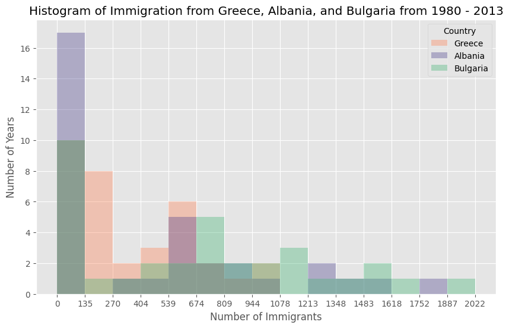

**`Result:`** An overlapping histogram for three Balkan countries. The distributions show how many years each country's immigration level fell into each bin range.

## 6. Bar Charts

Bar charts represent the magnitude of a variable (**numerically and categorically**) with the **length** of the bars. I'll explore both **vertical** `kind=bar` and **horizontal** `kind=barh` bar charts.

### Vertical Bar Plot - Iceland's Immigration Over Time

Let's look at Icelandic immigration to Canada. The 2008-2011 financial crisis had a major impact on Iceland's economy, so we might expect to see a change in emigration patterns.

```
df_iceland = df_can.loc['Iceland', years]
df_iceland.head()
```

```
1980    17
1981    33
1982    10
1983     9
1984    13
Name: Iceland, dtype: int64
```

```
df_iceland.plot(kind='bar', figsize=(10, 6))

plt.xlabel('Year')
plt.ylabel('Number of immigrants')
plt.title('Icelandic immigrants to Canada from 1980 to 2013')
plt.show()
```

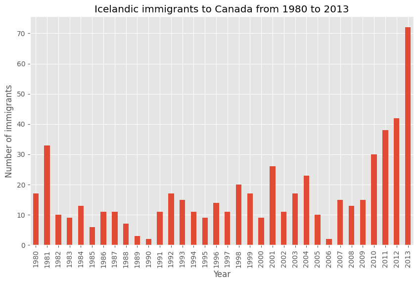

**`Result:`** A vertical bar chart showing Icelandic immigration year by year. A noticeable upward trend starts around 2008, coinciding with the financial crisis.

Let's add an **annotation to highlight** this:

for more details on annotations: https://matplotlib.org/stable/api/_as_gen/matplotlib.pyplot.annotate.html.

```
df_iceland.plot(kind='bar', figsize=(10, 6), rot=90) # rotate the xticks(labelled points on x-axis) by 90 degrees

plt.xlabel('Year')
plt.ylabel('Number of Immigrants')
plt.title('Icelandic Immigrants to Canada from 1980 to 2013')

plt.annotate('', # s: str. Will leave it blank for no text
             xy=(32, 70), # place head of the arrow at point (year 2012 , pop 70)
             xytext=(28, 20), # place base of the arrow at point (year 2008 , pop 20)
             xycoords='data', # will use the coordinate system of the object being annotated
             arrowprops=dict(arrowstyle='->', connectionstyle='arc3', color='blue', lw=2) # specifies connection style `arc3` straight line, color of arrow, and line width
             )
plt.show()
```

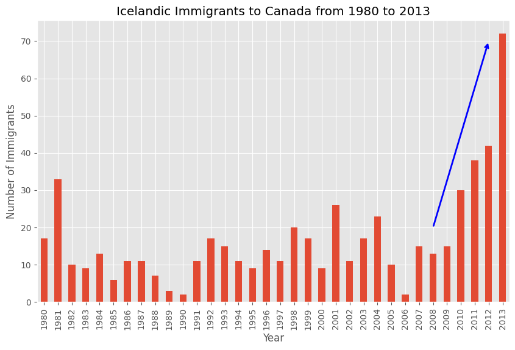

**`Result:`** Same bar chart with a blue arrow pointing from 2008 to 2012, highlighting the surge.

Let's add **explanatory text** alongside the arrow:

```
df_iceland.plot(kind='bar', figsize=(10, 6), rot=90)

plt.xlabel('Year')
plt.ylabel('Number of Immigrants')
plt.title('Icelandic Immigrants to Canada from 1980 to 2013')

plt.annotate('',
             xy=(32, 70),
             xytext=(28, 20),
             xycoords='data',
             arrowprops=dict(arrowstyle='->', connectionstyle='arc3', color='blue', lw=2)
             )

plt.annotate('2008 - 2011 Financial Crisis',
             xy=(28, 30), # start the text at at point (year 2008 , pop 30)
             rotation=72.5, # in degrees (counter clockwise) try&error
             va='bottom', # ‘center’ | ‘top’ | ‘bottom’ | ‘baseline’
             ha='left', # ‘center’ | ‘right’ | ‘left’
             )
plt.show()
```

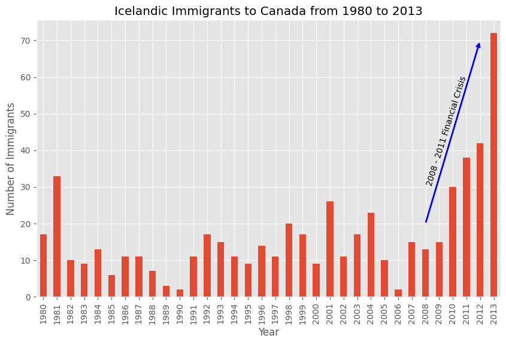

**`Result:`** An arrow and a text label explaining the 2008-2011 financial crisis. Annotations can tell a story within a visualization.

### Exercise: Horizontal Bar Plot - Top 15 Countries

**Task:** Create a horizontal bar plot showing the total number of immigrants to Canada from the **top 15 countries** (1980–2013). Label each bar with the total count.

**Step 1:** Get the top 15 countries by total immigration.

```
df_can.sort_values(by='Total', ascending=True, inplace=True)

df_top15 = df_can['Total'].tail(15)
df_top15
```

[output not shown]

**Step 2:** Plot as a horizontal bar chart with annotations.

```
df_top15.plot(kind='barh', figsize=(12, 12), color='steelblue')
plt.xlabel('Number of Immigrants')
plt.title('Top 15 Countries Contributing to the Immigration to Canada between 1980 - 2013')

for index, value in enumerate(df_top15):
    label = format(int(value), ',') # format int with commas

    # place text at the end of bar (subtracting 47000 from x, and 0.1 from y to make it fit within the bar)
    plt.annotate(label, xy=(value - 47000, index - 0.10), color='white')
plt.show()
```

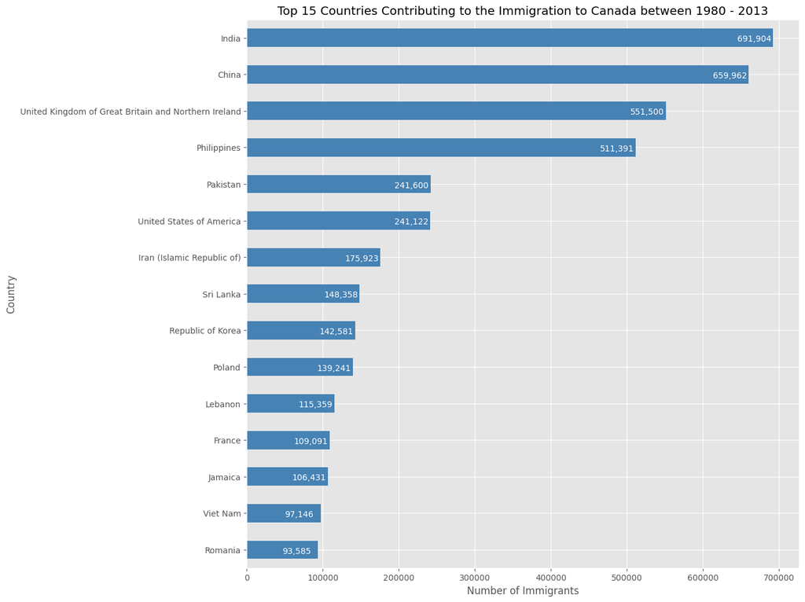

**`Result:`** A horizontal bar chart with white annotation showing the exact immigrant count.

**Why horizontal bars?** They leave more room for country labels on the y-axis, making them ideal for displaying many categories without overlapping text.

That's the full walkthrough. The dataset is cleaned, indexed by country, and visualized with area plots, histograms, and bar charts.